# Concrete_FMSTProject

# Model tuning using Hyper Parameters

```python
from pprint import pprint
rf = RandomForestRegressor(random_state = 1)
print('Parameters currently in use:\n')
pprint(rf.get_params())
```

```
Parameters currently in use:

{'bootstrap': True,
 'ccp_alpha': 0.0,
 'criterion': 'mse',
 'max_depth': None,
 'max_features': 'auto',
 'max_leaf_nodes': None,
 'max_samples': None,
 'min_impurity_decrease': 0.0,
 'min_impurity_split': None,
 'min_samples_leaf': 1,
 'min_samples_split': 2,
 'min_weight_fraction_leaf': 0.0,
 'n_estimators': 100,
 'n_jobs': None,
 'oob_score': False,
 'random_state': 1,
 'verbose': 0,
 'warm_start': False}
```

# RandomSearchCV

```python
import numpy as np
print(np.linspace(start = 5, stop = 10, num = 2))
```

```
[ 5. 10.]
```

```python
from sklearn.model_selection import RandomizedSearchCV

# Number of trees in random forest
n_estimators = [int(x) for x in np.linspace(start = 10 , stop = 15, num = 2)]   # returns evenly spaced 10 numbers
# Number of features to consider at every split
max_features = ['auto', 'log2']
# Maximum number of levels in tree
max_depth = [int(x) for x in np.linspace(5, 10, num = 2)]  # returns evenly spaced numbers can be changed to any
max_depth.append(None)
# Minimum number of samples required to split a node
min_samples_split = [2, 5, 10]
# Minimum number of samples required at each leaf node
min_samples_leaf = [1, 2, 4]
# Method of selecting samples for training each tree
bootstrap = [True, False]

# Create the random grid
random_grid = {'n_estimators': n_estimators,
               'max_features': max_features,
               'max_depth': max_depth,
               'min_samples_split': min_samples_split,
               'min_samples_leaf': min_samples_leaf,
               'bootstrap': bootstrap}

pprint(random_grid)
```

```
{'bootstrap': [True, False],
 'max_depth': [5, 10, None],
 'max_features': ['auto', 'log2'],
 'min_samples_leaf': [1, 2, 4],
 'min_samples_split': [2, 5, 10],
 'n_estimators': [10, 15]}
```

```python
# Use the random grid to search for best hyperparameters

# Random search of parameters, using 3 fold cross validation,
# search across 100 different combinations, and use all available cores
rf_random = RandomizedSearchCV(estimator=rf, param_distributions=random_grid,n_iter = 5, scoring='neg_mean_absolute_error',
                              cv = 3, verbose=2, random_state=42, n_jobs=-1,return_train_score=True)

# Fit the random search model
rf_random.fit(X_train_scaled, y_train);
```

```
Fitting 3 folds for each of 5 candidates, totalling 15 fits
```

```
[Parallel(n_jobs=-1)]: Using backend LokyBackend with 12 concurrent workers.
[Parallel(n_jobs=-1)]: Done   8 out of  15 | elapsed:    1.4s remaining:    1.2s
[Parallel(n_jobs=-1)]: Done  15 out of  15 | elapsed:    1.4s finished
```

```python
rf_random.best_params_
```

```
{'n_estimators': 15,
 'min_samples_split': 5,
 'min_samples_leaf': 1,
 'max_features': 'log2',
 'max_depth': None,
 'bootstrap': False}
```

```python
# best ensemble model (with optimal combination of hyperparameters)
best_randommodel = rf_random.best_estimator_
best_randommodel.score(X_test_scaled , y_test)
```

```
0.89385015543115
```

```python
train_score=best_randommodel.score(X_train_scaled, y_train)
test_score=best_randommodel.score(X_test_scaled , y_test)
tempDf = pd.DataFrame({'Method':['Random Forest Regressor'], 'Iteration':["3- with 4 columns using RandomSerachCV"], 'Train Score': train_score,'Test Score':test_score})
resultsDf = resultsDf.append(tempDf,ignore_index=True)
resultsDf
```

|  | Method | Iteration | Train Score | Test Score |
| --- | --- | --- | --- | --- |
| 0 | Linear Regression | 1-with all columns | 0.627147 | 0.584510 |
| 1 | Regularized Ridge Model | 1-with all columns | 0.626574 | 0.585189 |
| 2 | Regularized Lasso Model | 1-with all columns | 0.617593 | 0.580914 |
| 3 | Decision Tree Regressor | 1-with all columns | 0.995082 | 0.872980 |
| 4 | Decision Tree Regressor | 2- with 4 columns | 0.993459 | 0.850279 |
| 5 | GradientBoosting Regressor | 2- with 4 columns | 0.905118 | 0.850603 |
| 6 | Bagging Regressor | 2- with 4 columns | 0.979697 | 0.896528 |
| 7 | Random Forest Regressor | 2- with 4 columns | 0.980047 | 0.894274 |
| 8 | Random Forest Regressor | 3- with 4 columns using RandomSerachCV | 0.983703 | 0.893850 |

```python
#Results have decreased using randomsearchCV, this might be due to suboptimal combination of hyper parameters
```

# Gaussian Mixed Clustering

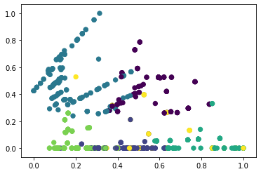

```python
# Plot the data with K Means Labels
from sklearn.cluster import KMeans
kmeans = KMeans(n_clusters= 6)
kmeans.fit(X_train_scaled)
labels = kmeans.labels_
plt.scatter(X_train_scaled[:, 0], X_train_scaled[:, 1], c=labels, s=40, cmap='viridis');
```

```python
# now let's try GMM clustering, which tries to fit normally-distributed clusters
from sklearn.mixture import GaussianMixture

gmm = GaussianMixture(n_components=4)
gmm.fit(X_train_scaled)

# predict the cluster for each data point
y_cluster_gmm = gmm.predict(X_train_scaled)
y_cluster_gmm
```

```
array([0, 3, 0, 2, 0, 3, 0, 3, 0, 0, 0, 3, 0, 0, 0, 2, 3, 0, 3, 2, 2, 0,
       1, 3, 3, 0, 0, 0, 0, 3, 3, 0, 3, 3, 0, 0, 0, 1, 2, 0, 2, 2, 1, 0,
       3, 0, 3, 3, 0, 0, 3, 3, 3, 3, 2, 3, 3, 0, 1, 0, 0, 0, 3, 0, 3, 1,
       0, 0, 1, 3, 1, 3, 1, 0, 3, 3, 0, 2, 1, 1, 3, 0, 0, 3, 0, 0, 0, 3,
       3, 1, 3, 2, 0, 1, 3, 1, 1, 2, 3, 1, 3, 1, 0, 1, 1, 0, 3, 0, 0, 3,
       3, 3, 3, 1, 0, 0, 2, 0, 3, 0, 0, 3, 3, 0, 0, 2, 1, 1, 1, 0, 3, 3,
       1, 3, 0, 0, 3, 0, 0, 3, 0, 0, 0, 3, 2, 3, 1, 0, 0, 0, 3, 0, 3, 0,
       0, 1, 3, 1, 3, 1, 2, 0, 0, 1, 0, 0, 0, 0, 0, 0, 1, 0, 3, 3, 0, 1,
       3, 3, 0, 1, 0, 2, 0, 3, 3, 2, 3, 3, 3, 1, 2, 1, 0, 3, 0, 0, 0, 0,
       1, 0, 0, 3, 2, 0, 1, 0, 2, 1, 1, 3, 1, 1, 0, 1, 3, 3, 3, 3, 3, 3,
       3, 0, 1, 0, 1, 3, 1, 0, 0, 0, 3, 0, 0, 3, 1, 1, 0, 0, 0, 0, 1, 0,
       1, 1, 0, 1, 1, 3, 3, 0, 1, 3, 0, 3, 0, 0, 3, 3, 0, 0, 0, 1, 0, 2,
       0, 0, 0, 2, 0, 3, 0, 0, 0, 3, 0, 0, 3, 3, 0, 0, 0, 3, 0, 0, 3, 3,
       0, 3, 3, 3, 2, 3, 3, 3, 1, 3, 0, 3, 3, 1, 0, 0, 3, 0, 0, 0, 3, 0,
       0, 0, 1, 0, 3, 2, 0, 3, 3, 0, 0, 3, 1, 0, 1, 0, 0, 0, 1, 0, 1, 0,
```

[output cut: 18 more lines]

[figure not shown]

```python
plt.scatter(X_train_scaled[:, 0], X_train_scaled[:, 1], c=labels, s=40, cmap='viridis');
```

```python
#Let's see the clusters for each independant variables
```

```
array([[<matplotlib.axes._subplots.AxesSubplot object at 0x13a5d1710>,
      dtype=object)
```

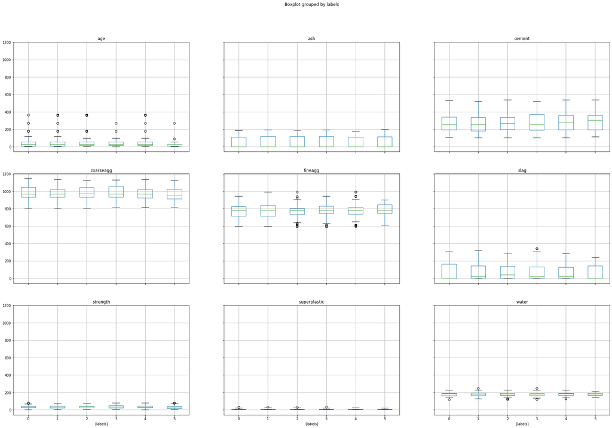

```python
## creating a new dataframe only for labels and converting it into categorical variable
cluster_labels = pd.DataFrame(kmeans.labels_ , columns = list(['labels']))
cluster_labels['labels'] = cluster_labels['labels'].astype('category')
condf_labeled = condf.join(cluster_labels)

condf_labeled.boxplot(by = 'labels',  layout=(3,3), figsize=(30, 20))
```

```python
#No distinct clusters are visible at any number of clusters. Looks like the attributes are weak predictors except for cement.
# The potential of getting better results by breaking data into clusters is unlikely to give the desired result
```

# Model performance range at 95% confidence level

# Configure bootstrap

The bootstrap is simulated resampling method where samples are drawn from a fixed finite concrete dataset with replacement and a parameter is estimated on each sample. This procedure leads to a robust estimate of the true population parameter via sampling. The procedure can be used to estimate the skill of a predictive model by fitting the model on each sample and evaluating the skill of the model on those samples not included in the sample

```python
concrete_XY = X.join(y)
```

```python
values = concrete_XY.values
n_iterations = 1000        # Number of bootstrap samples to create
n_size = int(len(condf) * 1)    # size of a bootstrap sample
# run bootstrap
stats = list()   # empty list that will hold the scores for each bootstrap iteration

for i in range(n_iterations):
    # prepare train and test sets
    train = resample(values, n_samples=n_size)  # Sampling with replacement
    test = np.array([x for x in values if x.tolist() not in train.tolist()])  # out of bag (OOB) samples -picking rest of the data not considered in sample


    # fit model
    rfTree = RandomForestRegressor(n_estimators=50)
    rfTree.fit(train[:,:-1], train[:,-1])   # fit against independent variables and corresponding target values
    y_test = test[:,-1]    # Take the target column for all rows in test set

    # evaluate model
    predictions = rfTree.predict(test[:, :-1])   # predict based on independent variables in the test data
    score = rfTree.score(test[:, :-1] , y_test)

    stats.append(score)
```

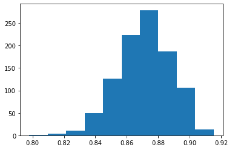

```
95.0 confidence interval 83.7% and 89.9%
```

```python
# plot scores

plt.hist(stats)
plt.show()

# confidence intervals
alpha = 0.95                             # for 95% confidence
p = ((1.0-alpha)/2.0) * 100              # tail regions on right and left .25 on each side indicated by P value (border)
lower = max(0.0, np.percentile(stats, p))
p = (alpha+((1.0-alpha)/2.0)) * 100
upper = min(1.0, np.percentile(stats, p))
print('%.1f confidence interval %.1f%% and %.1f%%' % (alpha*100, lower*100, upper*100))
```

```python
from numpy import median
print('50th percentile (median) = %.3f' % median(stats))
```

```
50th percentile (median) = 0.872
```

```python
So we can say that there is 95% likelihood that range 83.7% and 89.9% covers the true statistic mean of the model or what we are estimating about the population(the most likely value)

OR we can say that we are 95% confident that the real score for random forest regressor model on the unseen data is between  83.7% and 89.9% as well as it represents the margin of error or the amount of uncertainty around the sample mean
```